# CUBI advanced R bioinformatics course / 02

2020-05-15

## Why do we need functional data analysis?

```
##       Symbol                                           Description log(FC)      q
## 2180   APOL1                                     apolipoprotein L1     4.8 <2e-16
## 4586   MUC5B                mucin 5B, oligomeric mucus/gel-forming     5.4 <2e-16
## 12091    FOS Fos proto-oncogene, AP-1 transcription factor subunit     7.8 <2e-16
## 15198  ISG15                         ISG15 ubiquitin-like modifier     8.1 <2e-16
## 12150  STAT2    signal transducer and activator of transcription 2     3.6 <2e-16
## 19148    CFB                                   complement factor B     5.5 <2e-16
## 5228    SLPI               secretory leukocyte peptidase inhibitor     5.0 <2e-16
## 17662   IRF9                        interferon regulatory factor 9     3.6 <2e-16
## 8466  IGFBP1          insulin like growth factor binding protein 1     5.2 <2e-16
## 14777   IRF7                        interferon regulatory factor 7     6.8 <2e-16
## 1747    OAS1                     2'-5'-oligoadenylate synthetase 1     3.7 <2e-16
## 4188   CCL20                         C-C motif chemokine ligand 20     4.8 <2e-16
## 6477     NTS                                           neurotensin     8.0 <2e-16
## 5459      C3                                         complement C3     4.0 <2e-16
## 1754    CHGB                                        chromogranin B     4.3 <2e-16
## 12372    FGA                                fibrinogen alpha chain     3.1 <2e-16
## 8661    LCN2                                           lipocalin 2     5.4 <2e-16
## 7341   PARP9           poly(ADP-ribose) polymerase family member 9     3.8 <2e-16
## 771   PARP12          poly(ADP-ribose) polymerase family member 12     3.5 <2e-16
## 9632     MX1                              MX dynamin like GTPase 1     8.0 <2e-16
```

## Simple idea

- Group genes by some property (for example, interferon inducible genes)
- Look at the group as a whole

## Getting gene sets

## Overview

| Source |  |
| --- | --- |
| GO (Gene ontology) | Very general, quite detailed; many gene sets unfortunately useless; suitable also for other organisms |
| KEGG | Database of pathways from the Kyoto Encyclopaedia of Genes and Genomes |
| PID | Pathway Interaction Database (National Cancer Institute + Nature Publishing Group) |
| Reactome | Free online database |
| MSigDB | Meta-database, contains many sets of gene sets |
| tmod | Genes clustered by expression in human WBC |

There are many others (WikiPathways, BioCarta, BioCyc, MetaCyc, ConsensusPathDB). It is worth checking them out when looking for a particular pathway or gene set, or in a particular context.

It is also possible to use your own gene sets.

## MSigDB

MSigDB gene sets are divided into categories and sub-categories

[output not shown]

## MSigDB from R package

```r
library(msigdbr)
h <- msigdbr("Homo sapiens", "H")
nrow(h)
```

```
## [1] 7321
```

```r
head(h)
```

```
## # A tibble: 6 x 9
##   gs_id gs_name               gs_cat gs_subcat human_gene_symbol species_name entrez_gene gene_symbol sources
##   <chr> <chr>                 <chr>  <chr>     <chr>             <chr>              <int> <chr>       <chr>
## 1 M5905 HALLMARK_ADIPOGENESIS H      ""        ABCA1             Homo sapiens          19 ABCA1       <NA>
## 2 M5905 HALLMARK_ADIPOGENESIS H      ""        ABCB8             Homo sapiens       11194 ABCB8       <NA>
## 3 M5905 HALLMARK_ADIPOGENESIS H      ""        ACAA2             Homo sapiens       10449 ACAA2       <NA>
## 4 M5905 HALLMARK_ADIPOGENESIS H      ""        ACADL             Homo sapiens          33 ACADL       <NA>
## 5 M5905 HALLMARK_ADIPOGENESIS H      ""        ACADM             Homo sapiens          34 ACADM       <NA>
## 6 M5905 HALLMARK_ADIPOGENESIS H      ""        ACADS             Homo sapiens          35 ACADS       <NA>
```

## MSigDB directly (using tmod)

Download the file `msigdb_v7.1.xml` from https://www.gsea-msigdb.org/gsea/downloads.jsp (176 MB).

```r
library(tmod)
msig <- tmodImportMSigDB("msigdb_v7.1.xml")
msig
```

```
## An object of class "tmod"
##  22845 modules, 38370 genes
```

```r
head(msig$MODULES)
```

```
##            ID             Title Category    Subcategory EXTERNAL_DETAILS_URL   B
## M3128   M3128 Aaanwwtgc unknown       C3 TFT:TFT_Legacy                      194
## M11607 M11607 Aaayrnctg unknown       C3 TFT:TFT_Legacy                      374
## M12599 M12599           Myod 01       C3 TFT:TFT_Legacy                      269
## M5067   M5067            E47 01       C3 TFT:TFT_Legacy                      254
## M10817 M10817           Cmyb 01       C3 TFT:TFT_Legacy                      253
## M16694 M16694            Ap4 01       C3 TFT:TFT_Legacy                      264
```

## tmod gene expression modules

```r
data(tmod)
tmod
```

```
## An object of class "tmod"
##  606 modules, 12712 genes
```

```r
head(tmod$MODULES)
```

```
##              ID                                   Title           Category Annotated                                                                       URL
## LI.M0     LI.M0                      targets of FOSL1/2         TF targets       Yes   http://www.interactivefigures.com/meni/btm416_annotation/btmdata/M0.htm
## LI.M1.0 LI.M1.0  integrin cell surface interactions (I) molecular function       Yes http://www.interactivefigures.com/meni/btm416_annotation/btmdata/M1.0.htm
## LI.M1.1 LI.M1.1 integrin cell surface interactions (II) molecular function       Yes http://www.interactivefigures.com/meni/btm416_annotation/btmdata/M1.1.htm
## LI.M2.0 LI.M2.0                extracellular matrix (I)           location       Yes http://www.interactivefigures.com/meni/btm416_annotation/btmdata/M2.0.htm
## LI.M2.1 LI.M2.1               extracellular matrix (II)           location       Yes http://www.interactivefigures.com/meni/btm416_annotation/btmdata/M2.1.htm
## LI.M2.2 LI.M2.2              extracellular matrix (III)           location       Yes http://www.interactivefigures.com/meni/btm416_annotation/btmdata/M2.2.htm
##                 Source SourceID original.ID  B
## LI.M0   Li et al. 2013       LI          M0 12
## LI.M1.0 Li et al. 2013       LI        M1.0 29
## LI.M1.1 Li et al. 2013       LI        M1.1 12
## LI.M2.0 Li et al. 2013       LI        M2.0 30
## LI.M2.1 Li et al. 2013       LI        M2.1 45
## LI.M2.2 Li et al. 2013       LI        M2.2 14
```

## tmod object

Tmod object is a list with two mandatory elements:

- `MODULES`: data frame describing the gene sets
- `MODULES2GENES`: list mapping modules to genes

```r
head(msig$MODULES[ msig$MODULES$Category == "H", ])
```

```
##          ID                               Title Category Subcategory EXTERNAL_DETAILS_URL   B
## M5890 M5890    Hallmark tnfa signaling via nfkb        H                                  200
## M5891 M5891                    Hallmark hypoxia        H                                  200
## M5892 M5892    Hallmark cholesterol homeostasis        H                                   74
## M5893 M5893            Hallmark mitotic spindle        H                                  199
## M5895 M5895 Hallmark wnt beta catenin signaling        H                                   42
## M5896 M5896         Hallmark tgf beta signaling        H                                   54
```

```r
msig$MODULES2GENES[["M5944"]]
```

```
##  [1] "VCAN"     "POSTN"    "FSTL1"    "LRPAP1"   "STC1"     "LPL"      "VEGFA"    "PF4"      "THBD"     "FGFR1"    "TNFRSF21" "CCND2"    "COL5A2"   "ITGAV"    "SERPINA5"
## [16] "KCNJ8"    "APP"      "JAG1"     "COL3A1"   "SPP1"     "NRP1"     "OLR1"     "PDGFA"    "PTK2"     "SLCO2A1"  "PGLYRP1"  "VAV2"     "S100A4"   "MSX1"     "VTN"
## [31] "TIMP1"    "APOH"     "PRG2"     "JAG2"     "LUM"      "CXCL6"
```

## 1st generation algorithms

## 1st generation

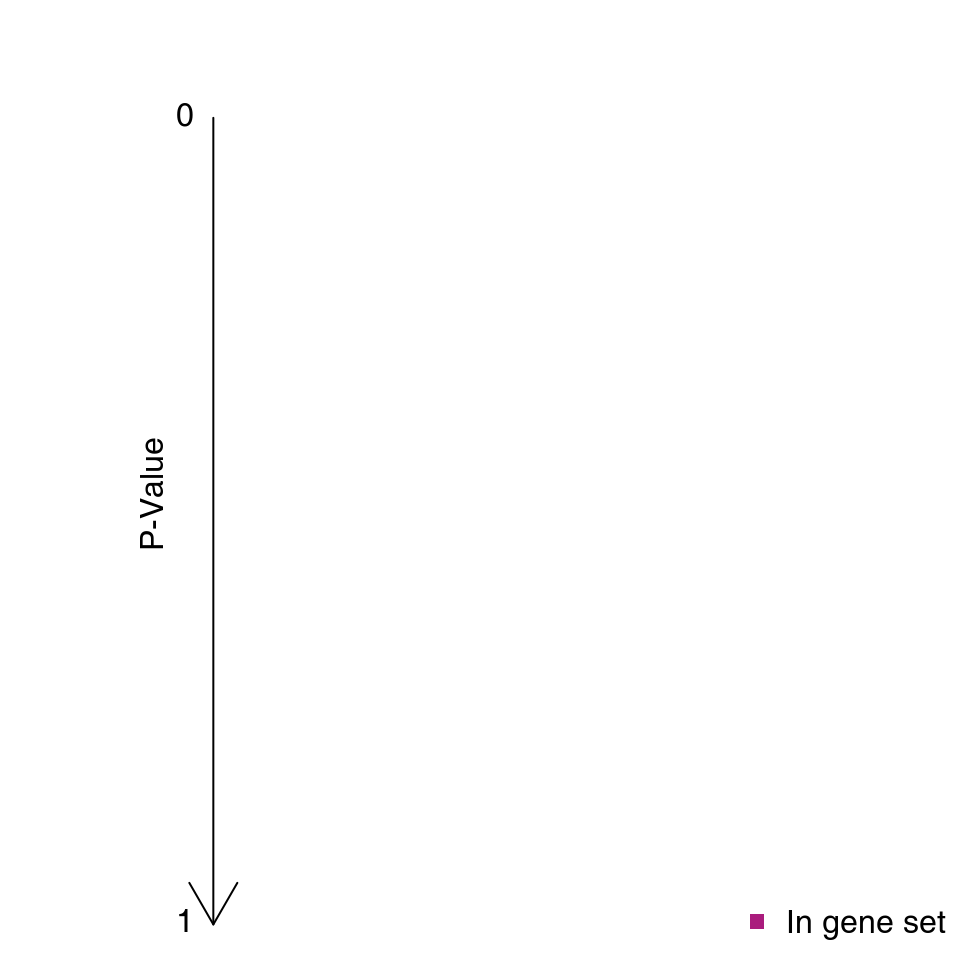

## 1st generation

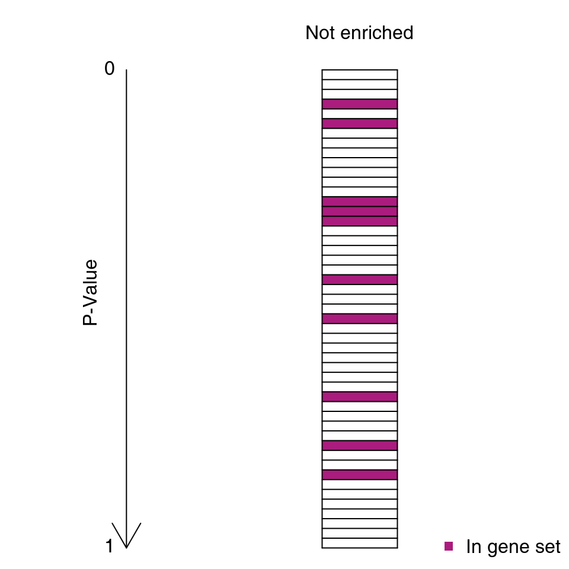

## 1st generation

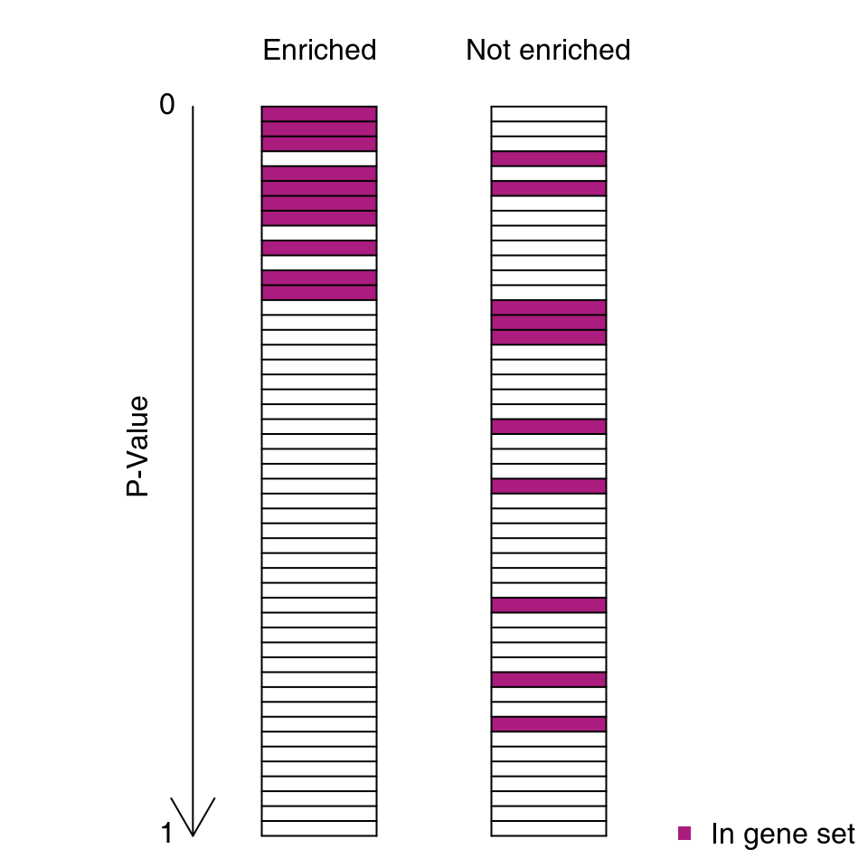

## 1st generation

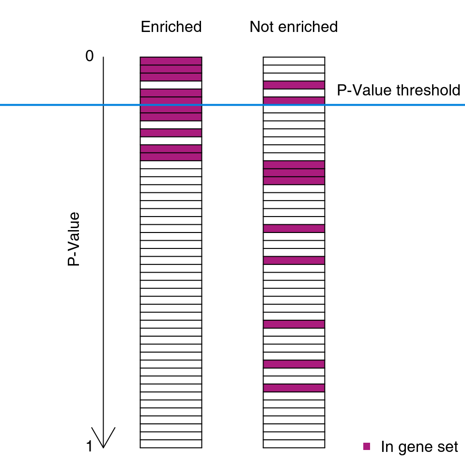

## 1st generation

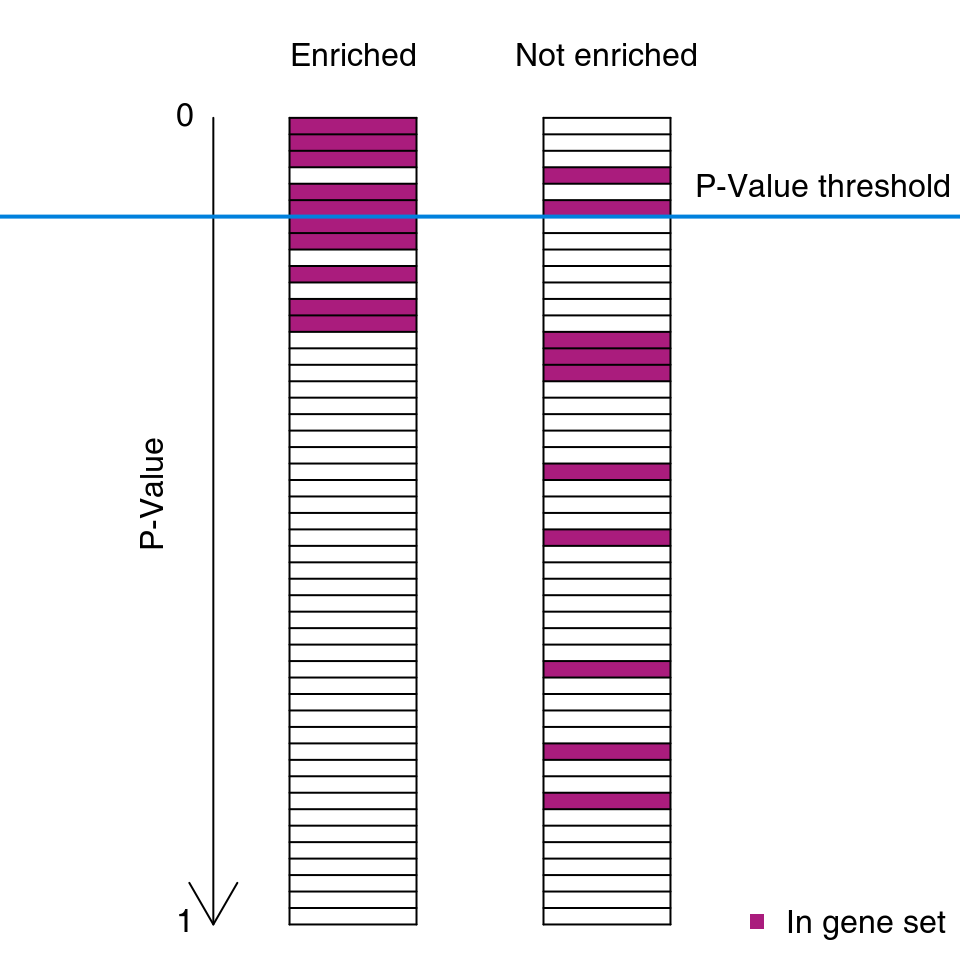

Enriched (left):

|  | In gene set | Total |
| --- | --- | --- |
| Significant | 5 | 6 |
| Total | 10 | 50 |

Not enriched (right):

|  | In gene set | Total |
| --- | --- | --- |
| Significant | 2 | 6 |
| Total | 10 | 50 |

## Possible tests

- \(\chi^2\) test: `chisq.test()`
- Fisher's exact test: `fisher.test()`
- hypergeometric test: `phyper()`

## \(\chi^2\) test

- b: number of genes significant and in gene set
- n: total number of significant genes
- B: total number of genes in gene set
- N: total number of genes

Contingency table:

|  | In gene set | Not in gene set |
| --- | --- | --- |
| significant | \(b\) | \(n - b\) |
| not significant | \(B - b\) | \((N-n) - (B-b)\) |

## Contingency tables

Easier method of getting the contingency table is using the `table` function.

```r
ex1 # example 1: enriched
```

```
##  [1] 1 1 1 0 1 1 1 1 0 1 0 1 1 0 0 0 0 0 0 0 0 0 0 0 0 0 0 0 0 0 0 0 0 0 0 0 0 0 0 0 0 0 0 0 0 0 0 0 0 0
```

```r
## we define first six genes to be significant
sign <- c(rep(TRUE, 6), rep(FALSE, length(ex1) - 6))
sign
```

```
##  [1]  TRUE  TRUE  TRUE  TRUE  TRUE  TRUE FALSE FALSE FALSE FALSE FALSE FALSE FALSE FALSE FALSE FALSE FALSE FALSE FALSE FALSE FALSE FALSE FALSE FALSE FALSE FALSE FALSE
## [28] FALSE FALSE FALSE FALSE FALSE FALSE FALSE FALSE FALSE FALSE FALSE FALSE FALSE FALSE FALSE FALSE FALSE FALSE FALSE FALSE FALSE FALSE FALSE
```

```r
table(ex1, sign)
```

```
##    sign
## ex1 FALSE TRUE
##   0    39    1
##   1     5    5
```

## \(\chi^2\) test: Enriched

- b: number of genes significant and in gene set
- n: total number of significant genes
- B: total number of genes in gene set
- N: total number of genes

```r
ct1 <- matrix(c(b1, n1-b1, B1-b1, (N1-n1)-(B1-b1)), nrow=2)
ct1
```

```
##      [,1] [,2]
## [1,]    5    5
## [2,]    1   39
```

```r
chisq.test(ct1)
```

```
##
##  Pearson's Chi-squared test with Yates' continuity correction
##
## data:  ct1
## X-squared = 12.891, df = 1, p-value = 0.0003302
```

## \(\chi^2\) test: Not enriched

- b: number of genes significant and in gene set
- n: total number of significant genes
- B: total number of genes in gene set
- N: total number of genes

```r
ct2 <- matrix(c(b2, n2-b2, B2-b2, (N2-n2)-(B2-b2)), nrow=2)
chisq.test(ct2)
```

```
##
##  Pearson's Chi-squared test with Yates' continuity correction
##
## data:  ct2
## X-squared = 0.10653, df = 1, p-value = 0.7441
```

## Example: interferon genes in A549 RSV vs mock

```r
gs <- tmod$MODULES2GENES[["LI.M127"]]
in_gs <- res$SYMBOL %in% gs
sign  <- !is.na(res$padj) & res$padj < .01 & abs(res$log2FoldChange) > 1
table(in_gs, sign)
```

```
##        sign
## in_gs   FALSE  TRUE
##   FALSE 17123  4129
##   TRUE      0    12
```

```r
chisq.test(table(in_gs, sign))
```

```
##
##  Pearson's Chi-squared test with Yates' continuity correction
##
## data:  table(in_gs, sign)
## X-squared = 44.643, df = 1, p-value = 2.364e-11
```

## Fisher's exact test: Enriched

```r
fisher.test(ct1, alternative="greater")
```

```
##
##  Fisher's Exact Test for Count Data
##
## data:  ct1
## p-value = 0.0006475
## alternative hypothesis: true odds ratio is greater than 1
## 95 percent confidence interval:
##  4.009906      Inf
## sample estimates:
## odds ratio
##   34.15309
```

## Fisher's exact test: Not enriched

```r
fisher.test(ct2, alternative="greater")
```

```
##
##  Fisher's Exact Test for Count Data
##
## data:  ct2
## p-value = 0.3444
## alternative hypothesis: true odds ratio is greater than 1
## 95 percent confidence interval:
##  0.256276      Inf
## sample estimates:
## odds ratio
##    2.20704
```

## Example: interferon genes in A549 RSV vs mock

```r
gs <- tmod$MODULES2GENES[["LI.M127"]]
in_gs <- res$SYMBOL %in% gs
sign  <- !is.na(res$padj) & res$padj < .01 & abs(res$log2FoldChange) > 1
table(in_gs, sign)
```

```
##        sign
## in_gs   FALSE  TRUE
##   FALSE 17123  4129
##   TRUE      0    12
```

```r
fisher.test(table(in_gs, sign))
```

```
##
##  Fisher's Exact Test for Count Data
##
## data:  table(in_gs, sign)
## p-value = 2.937e-09
## alternative hypothesis: true odds ratio is not equal to 1
## 95 percent confidence interval:
##  11.5151     Inf
## sample estimates:
## odds ratio
##        Inf
```

## Effect sizes in 1st generation

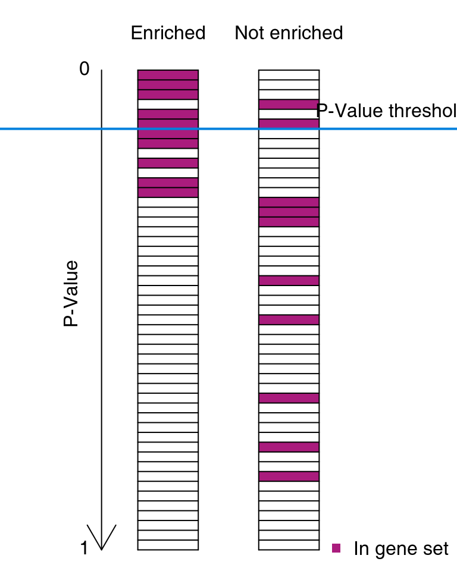

E – Enrichment strength; equivalent to RR (risk ratio)

\(E = \frac{\frac{b}{n}}{\frac{B}{N}} = \frac{b}{B}\cdot\frac{N}{n}\)

```r
## Enrichment
(b1/n1)/(B1/N1)
```

```
## [1] 4.166667
```

```r
## No enrichment
(b2/n2)/(B2/N2)
```

```
## [1] 1.666667
```

## Effect sizes in 1st generation

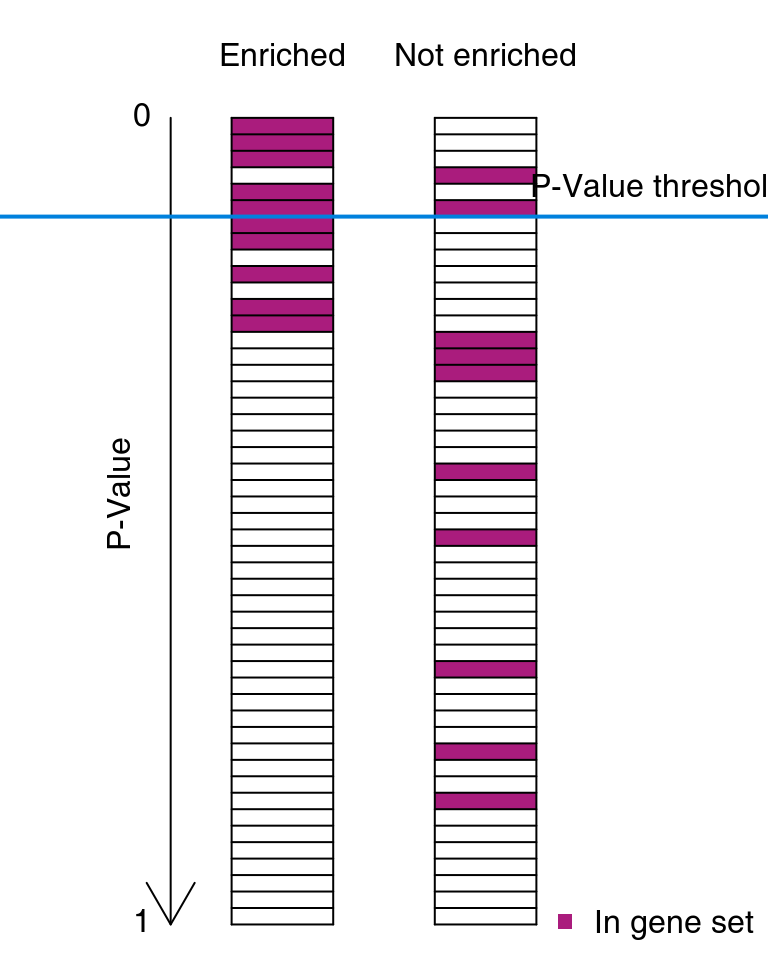

OR – Odds ratio

\(E = \frac{\frac{b}{n}}{\frac{B-b}{N-n}} = \frac{b}{B-b}\cdot\frac{N-n}{n}\)

```r
## Enrichment
(b1/n1)/((B1-b1)/(N1-n1))
```

```
## [1] 7.333333
```

```r
## No enrichment
(b2/n2)/((B2-b2)/(N2-n2))
```

```
## [1] 1.833333
```

## Alternative?

Alternative refers to the alternative hypothesis.

- `greater`: the odds ratio (OR) for a gene belong to the gene set is *higher* in foreground than in background
- `less`: the odds ratio (OR) for a gene belong to the gene set is *smaller* in foreground than in background
- `two.sided`: the odds ratio (OR) for a gene belong to the gene set is *different* in foreground than in background

## Hypergeometric test

Basically the same as Fisher's exact test (which tests the same assumptions), but with a different interface:

`phyper(q, m, n, k, lower.tail=FALSE)`

- q: significant and in gene set (=b)
- m: in gene set (=B)
- n: not in gene set (=N-B)
- k: significant (=n)

## Hypergeometric test

```r
## Enriched
phyper(b1 - 1, B1, N1-B1, n1, lower.tail=FALSE)
```

```
## [1] 0.0006475486
```

```r
## Not enriched
phyper(b2 - 1, B2, N2-B2, n2, lower.tail=FALSE)
```

```
## [1] 0.3443675
```

## \(\chi^2\) vs Fisher/hypergeometric

\(\chi^2\) test is widely considered inferior – it is an approximation only. It is especially inaccurate for small sample sizes (doesn't matter for gene set enrichment analysis). It has a tendency to give lower p-values.

In R, \(\chi^2\) is marginally faster.

## Fisher vs hypergeometric

These two are the same, but:

- `phyper` is much, much faster
- `fisher.test` can compute confidence intervals for the OR
- `fisher.test` can compute a two tailed test (`two.sided`)

## The problem with first generation

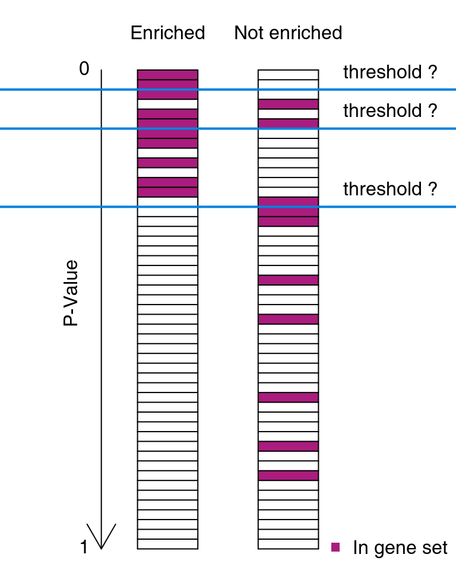

The results strongly depend on the threshold set *in relation to the p-values obtained*. These will depend on statistical power: more samples means lower p-values, more noise means higher p-values. The same threshold of e.g. 0.05 will have different effects depending on the particular samples used.

## 1st generation

When to use 1st generation tests:

- Whenever you compare two categories, eg. "predicted target of a transcription factor" vs "belongs to category X"

When *not* to use 1st generation test:

- Whenever you can use 2nd generation test ;)

## How to run it

- topGO (specifically for GO)
- clusterProfiler (also GSEA, see below)
- tmod (also CERNO and a couple of others, see below)

## HG with tmodHGtest

```r
options(digits=2)
res.hg <- tmodHGtest(fg=res$SYMBOL[sign], bg=res$SYMBOL)
head(res.hg, 15)
```

```
##                ID                                        Title   b   B    n     N   E P.Value adj.P.Val
## LI.M4.1   LI.M4.1                               cell cycle (I) 118 140 4141 21238 4.3 1.1e-61   3.8e-59
## LI.M4.0   LI.M4.0                 cell cycle and transcription 194 323 4141 21238 3.1 1.2e-58   2.0e-56
## LI.M6       LI.M6                        mitotic cell division  26  28 4141 21238 4.8 8.1e-17   9.4e-15
## LI.M4.2   LI.M4.2                        PLK1 signaling events  28  32 4141 21238 4.5 1.9e-16   1.7e-14
## LI.M103   LI.M103                             cell cycle (III)  35  51 4141 21238 3.5 3.2e-14   2.2e-12
## LI.M4.5   LI.M4.5 mitotic cell cycle in stimulated CD4 T cells  26  32 4141 21238 4.2 8.5e-14   4.9e-12
## LI.M4.4   LI.M4.4         mitotic cell cycle - DNA replication  24  30 4141 21238 4.1 1.5e-12   7.4e-11
## LI.M4.6   LI.M4.6      cell division in stimulated CD4 T cells  19  22 4141 21238 4.4 2.6e-11   1.1e-09
## LI.M22.0 LI.M22.0                          mismatch repair (I)  21  27 4141 21238 4.0 1.0e-10   3.9e-09
## LI.M8       LI.M8             E2F transcription factor network  15  16 4141 21238 4.8 2.9e-10   9.9e-09
## LI.M165   LI.M165   enriched in activated dendritic cells (II)  24  35 4141 21238 3.5 3.7e-10   1.2e-08
## LI.M127   LI.M127                   type I interferon response  12  12 4141 21238 5.1 3.0e-09   8.6e-08
## LI.M4.7   LI.M4.7                           mitotic cell cycle  16  20 4141 21238 4.1 9.2e-09   2.5e-07
## LI.M46     LI.M46        cell division stimulated CD4+ T cells  18  26 4141 21238 3.6 5.0e-08   1.2e-06
## LI.M75     LI.M75                      antiviral IFN signature  16  22 4141 21238 3.7 9.5e-08   2.2e-06
```

## 2nd generation algorithms

## 2nd generation algorithms

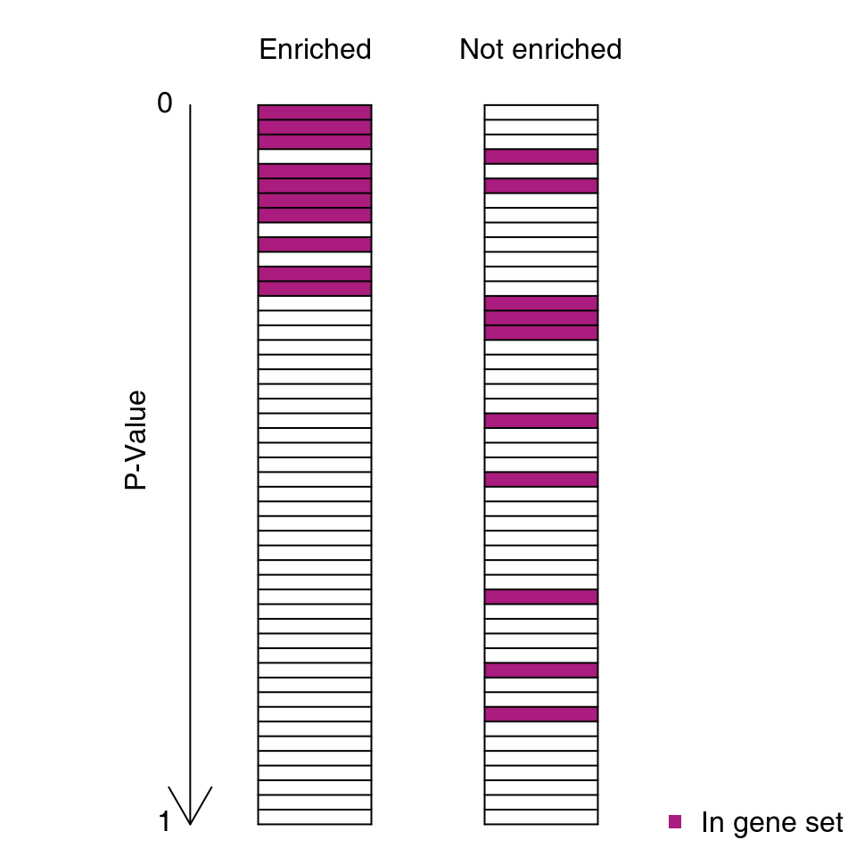

1. Order genes (e.g. by p-value)
2. Do the genes from a gene set of interest "float" to the top?

## Area under curve

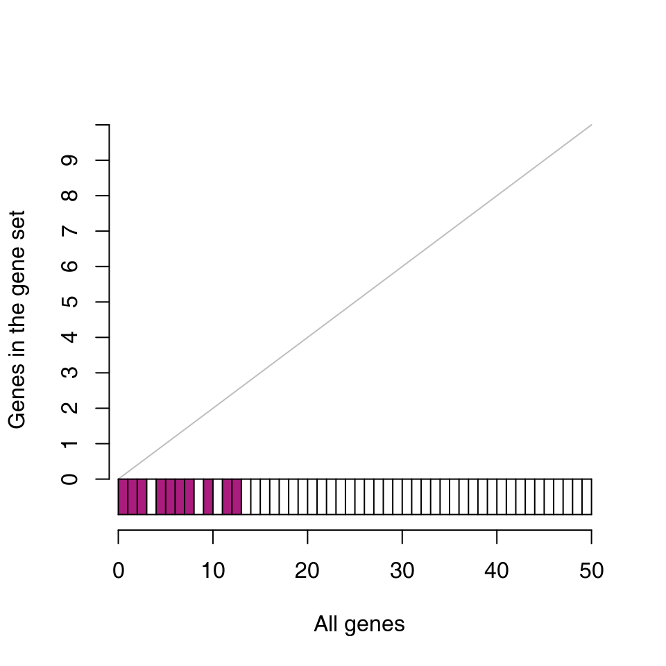

We proceed along the list of genes ordered by some property – most commonly, p-value. It is better to order slides by p-value than by q-value.

## Area under curve

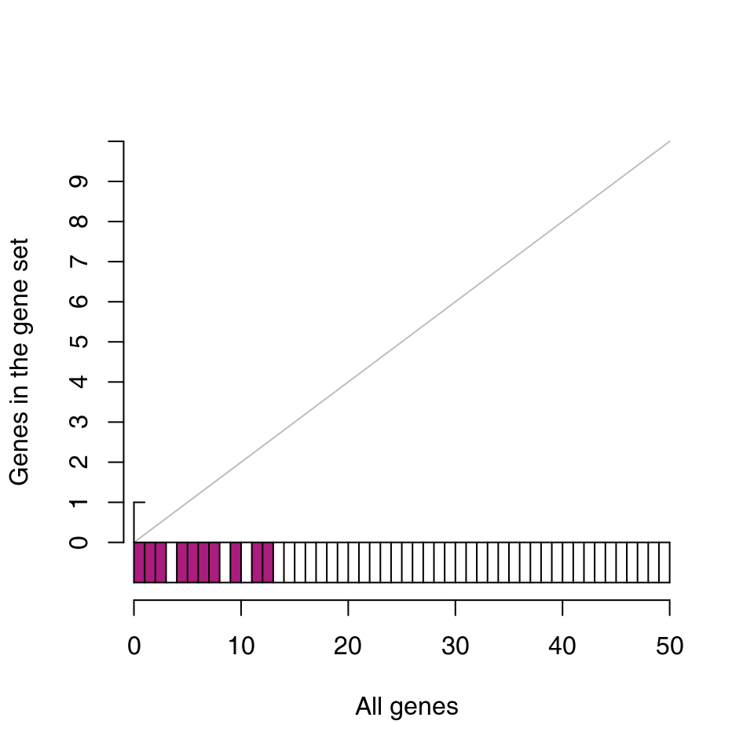

While proceeding, if a gene belongs to the gene set, we go up.

## Area under curve

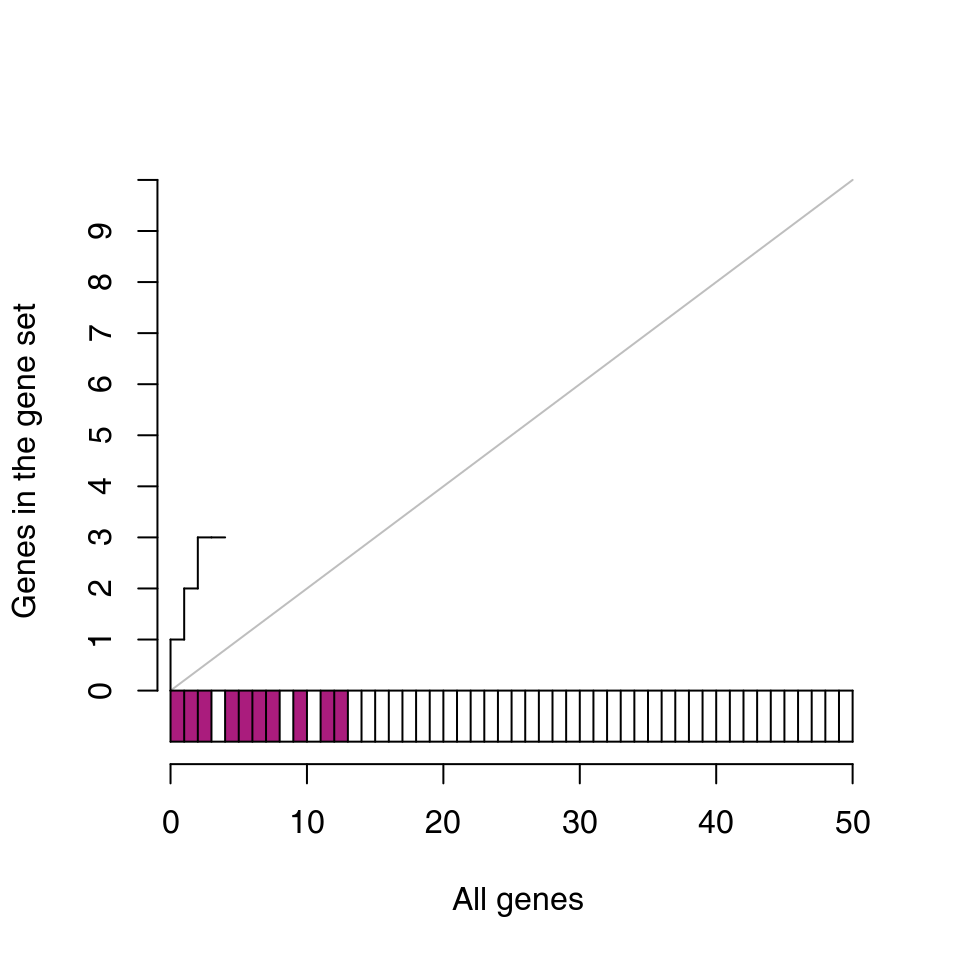

While proceeding, if a gene belongs to the gene set, we go up.

Otherwise, we go right.

## Area under curve

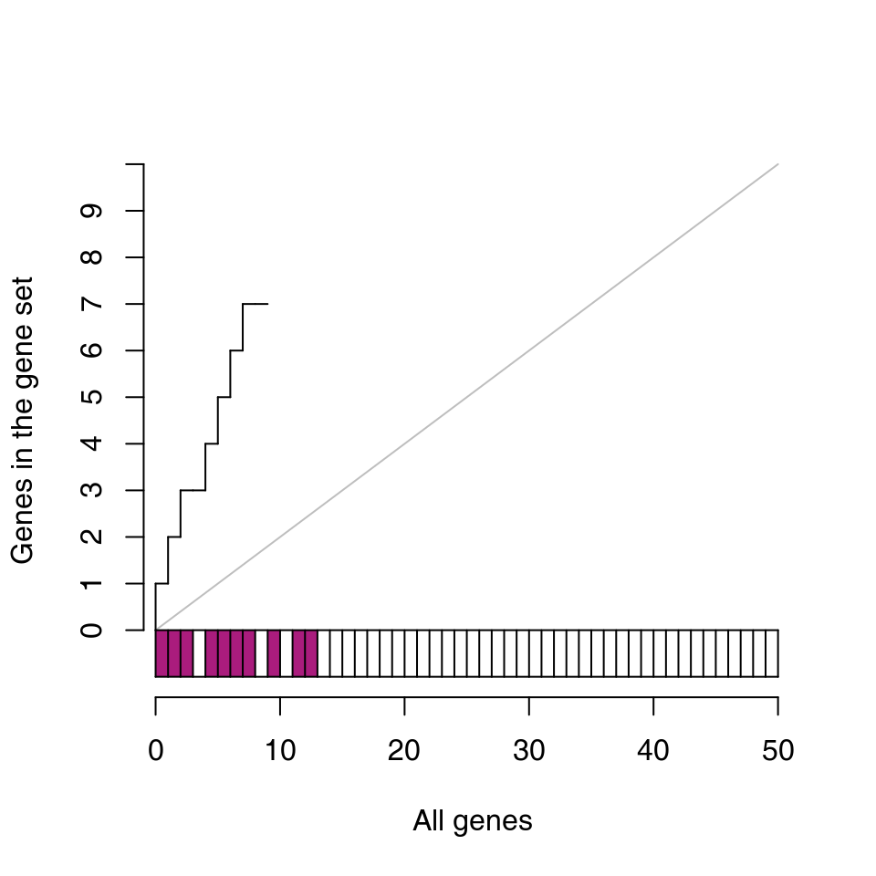

While proceeding, if a gene belongs to the gene set, we go up.

Otherwise, we go right.

And so on.

## Area under curve

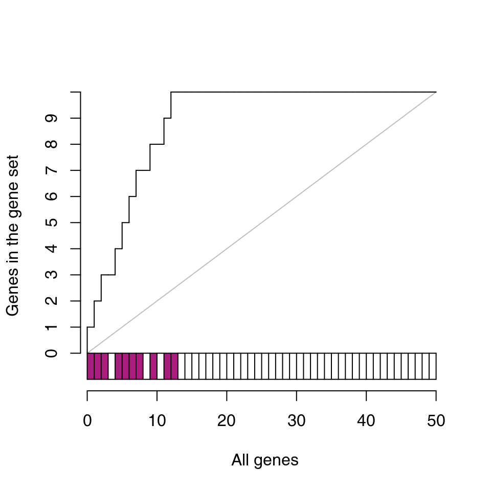

While proceeding, if a gene belongs to the gene set, we go up.

Otherwise, we go right.

And so on.

(Note that for demonstration purposes, when encountering a gene from a gene set, we also go right, but that is purely to show you the logic of the procedure)

## Area under curve

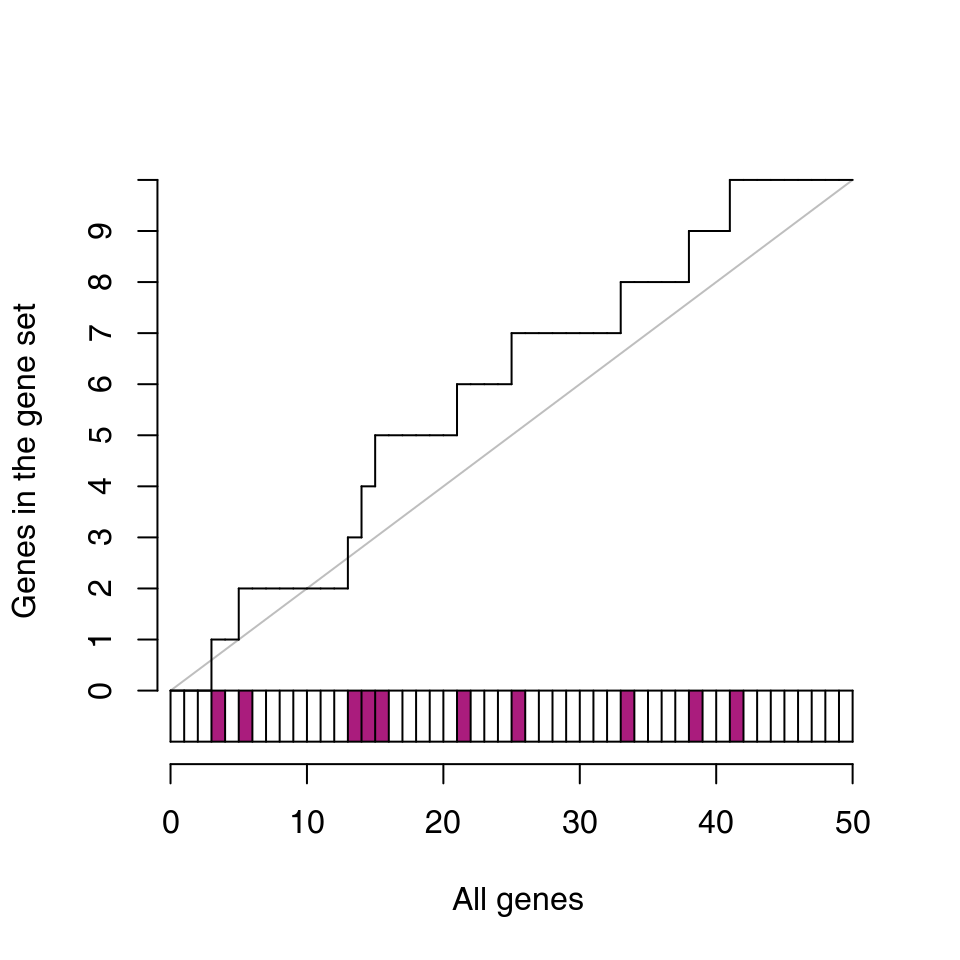

Non significant enrichments will have a curve close to the diagonal.

## Real example: interferon genes

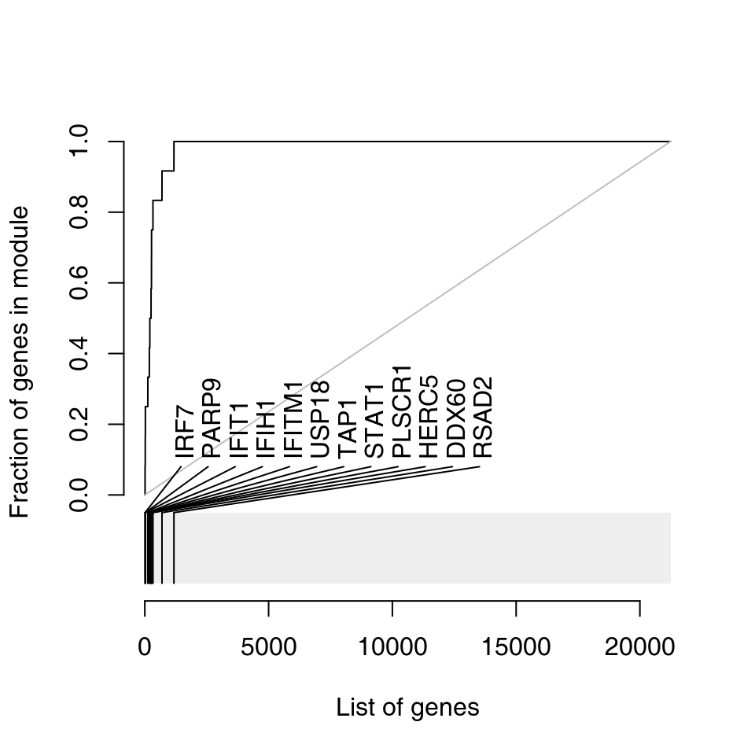

```r
evidencePlot(res$SYMBOL, m="LI.M127", gene.labels=TRUE)
```

## Real example: B-cell development

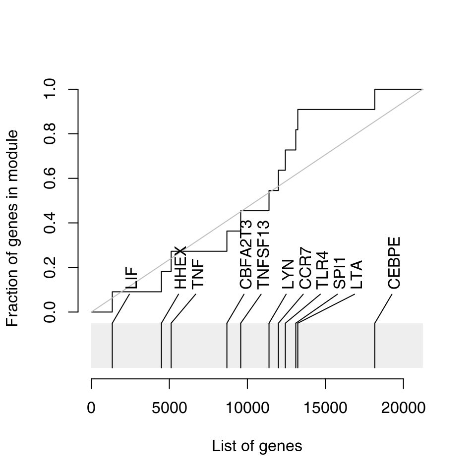

## Real example: Monocyte surface signature

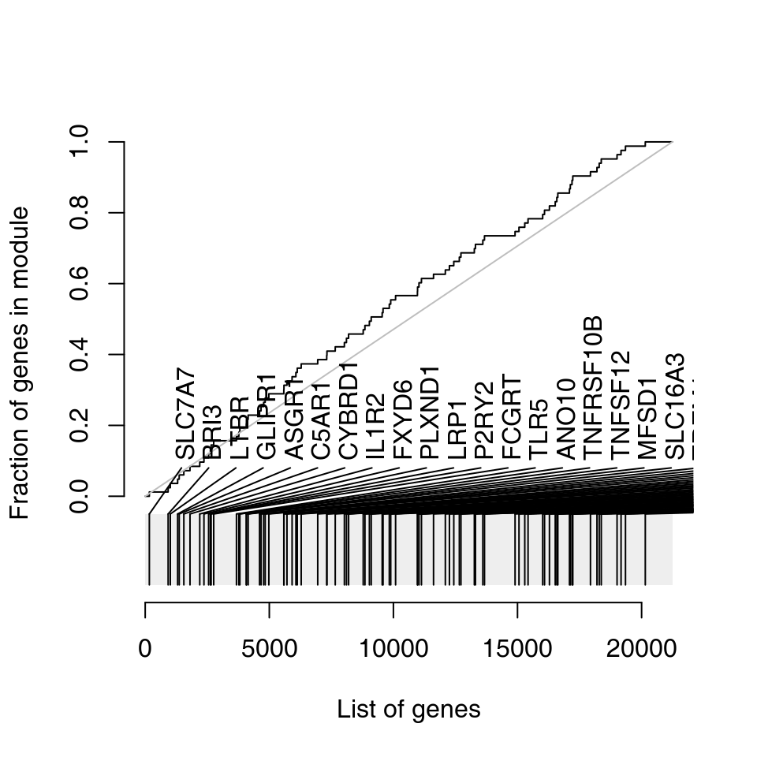

## Real example: Immune activation – generic cluster

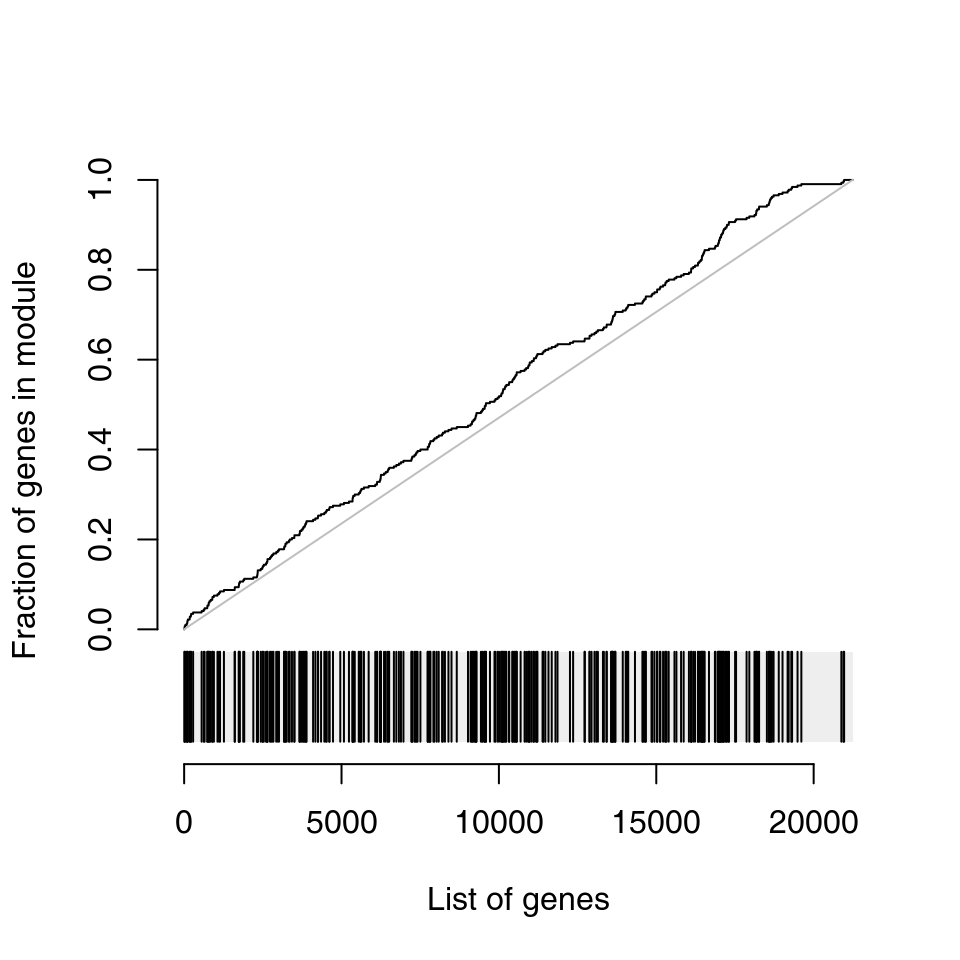

Why is it important to look at the AUC: in the enrichment test, this gene set is found to be significant!

## Calculating enrichment

- GSEA ("Gene set enrichment analysis") from Broad institute
- tmod (from me)

## GSEA

- Based on a randomization approach: calculate the statistics, then randomize the samples 1000x (or so) and calculate the statistics each time.
- If number of samples is small, GSEA randomizes *genes* rather than samples (which is not good!)
- The default Java app is cumbersome (does not run in R).
- The implementation in R (DOSE) only permutes genes.

## GSEA

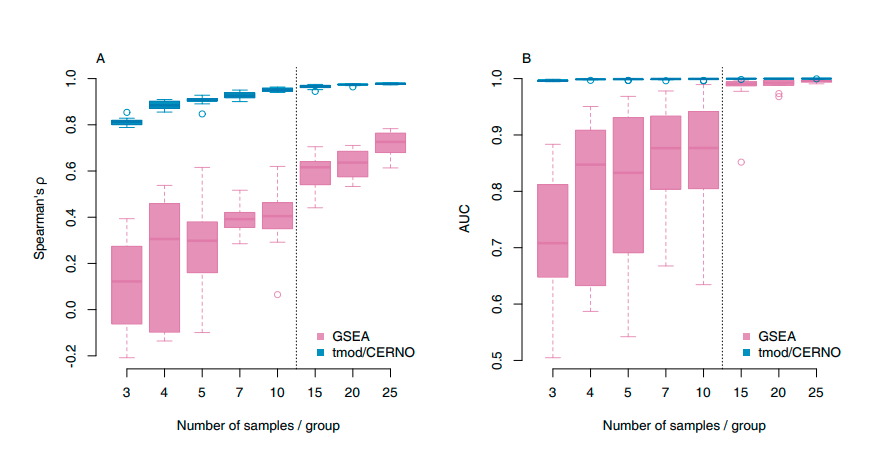

Comparison between tmod and GSEA

## tmod

Based on the CERNO statistics.

Given a ranked gene list, the rank of a gene divided by total number of genes, \(\frac{r_i}{N}\) follows a uniform distribution.

Therefore, it can be shown that \(-\log(\frac{r_i}{N})\) follows an exponential distribution. If we multiply an exponential distribution by factor \(2\), we get a \(\chi^2\) distribution.

Sum of \(\chi^2\) distribution is also a \(\chi^2\) distribution.

Therefore, all we need to do to calculate the p-value for a gene set GS, is to calculate

\[t_{\text{CERNO}}=-2\cdot\sum_{i \in \text{GS}}\log\left(\frac{r_i}{N}\right)\]

## tmod

- No need for randomization
- Super fast
- Problem: genes are correlated, while the above calculations assume independence, therefore -> False positives

## Running tmod

```r
options(digits=2)
tmod.res <- tmodCERNOtest(res$SYMBOL)
head(tmod.res, 15)
```

```
##                ID                                        Title cerno  N1  AUC cES P.Value adj.P.Val
## LI.M4.0   LI.M4.0                 cell cycle and transcription  1400 323 0.75 2.2 9.8e-58   3.4e-55
## LI.M4.1   LI.M4.1                               cell cycle (I)   830 140 0.90 3.0 7.2e-56   1.2e-53
## LI.M4.2   LI.M4.2                        PLK1 signaling events   201  32 0.91 3.1 4.9e-16   5.6e-14
## LI.M127   LI.M127                   type I interferon response   120  12 0.99 5.0 1.2e-14   1.0e-12
## LI.M103   LI.M103                             cell cycle (III)   250  51 0.82 2.4 2.2e-14   1.5e-12
## LI.M6       LI.M6                        mitotic cell division   169  28 0.91 3.0 2.5e-13   1.5e-11
## LI.M165   LI.M165   enriched in activated dendritic cells (II)   189  35 0.77 2.7 6.5e-13   3.2e-11
## LI.M150   LI.M150                    innate antiviral response   105  12 0.88 4.4 3.6e-12   1.6e-10
## LI.M22.0 LI.M22.0                          mismatch repair (I)   157  27 0.90 2.9 5.3e-12   2.1e-10
## LI.M75     LI.M75                      antiviral IFN signature   138  22 0.79 3.1 1.2e-11   4.0e-10
## LI.M4.4   LI.M4.4         mitotic cell cycle - DNA replication   161  30 0.88 2.7 3.8e-11   1.2e-09
## LI.M4.5   LI.M4.5 mitotic cell cycle in stimulated CD4 T cells   166  32 0.82 2.6 5.6e-11   1.6e-09
## LI.M20     LI.M20            AP-1 transcription factor network   104  14 0.88 3.7 1.2e-10   3.2e-09
## LI.M68     LI.M68                RIG-1 like receptor signaling    85   9 0.94 4.7 1.3e-10   3.2e-09
## LI.M4.7   LI.M4.7                           mitotic cell cycle   116  20 0.88 2.9 2.5e-09   5.9e-08
```

## Running tmod on MSigDB

```r
options(digits=2)
tmod.res.msigdb <- tmodCERNOtest(res$SYMBOL, mset=msig[ msig$MODULES$Category == "H" ])
head(tmod.res.msigdb, 15)
```

```
##          ID                                      Title cerno  N1  AUC cES P.Value adj.P.Val
## M5913 M5913         Hallmark interferon gamma response  1079 197 0.76 2.7 4.9e-65   2.4e-63
## M5911 M5911         Hallmark interferon alpha response   719  94 0.92 3.8 3.5e-63   8.9e-62
## M5890 M5890           Hallmark tnfa signaling via nfkb   909 197 0.77 2.3 1.1e-42   1.9e-41
## M5925 M5925                       Hallmark e2f targets   891 195 0.81 2.3 3.8e-41   4.7e-40
## M5901 M5901                    Hallmark g2m checkpoint   855 190 0.81 2.2 1.5e-38   1.5e-37
## M5893 M5893                   Hallmark mitotic spindle   782 196 0.77 2.0 3.1e-28   2.6e-27
## M5891 M5891                           Hallmark hypoxia   717 191 0.69 1.9 9.9e-23   7.1e-22
## M5907 M5907            Hallmark estrogen response late   698 196 0.68 1.8 1.5e-19   9.3e-19
## M5921 M5921                        Hallmark complement   700 197 0.68 1.8 2.1e-19   1.2e-18
## M5902 M5902                         Hallmark apoptosis   569 158 0.71 1.8 1.1e-16   5.4e-16
## M5930 M5930 Hallmark epithelial mesenchymal transition   663 195 0.67 1.7 2.0e-16   9.1e-16
## M5906 M5906           Hallmark estrogen response early   656 195 0.69 1.7 7.3e-16   3.1e-15
## M5924 M5924                  Hallmark mtorc1 signaling   651 194 0.69 1.7 1.2e-15   4.7e-15
## M5937 M5937                        Hallmark glycolysis   646 198 0.69 1.6 3.0e-14   1.1e-13
## M5946 M5946                       Hallmark coagulation   484 137 0.65 1.8 8.6e-14   2.9e-13
```

## Visualizing tmod results

tmod results (or, for that matter, results from other gene set enrichment analysis tools) can be visualized with the function `tmodPanelPlot`. This can show you the results simultaneously of many different enrichment analyses (e.g. for each contrast).

Parameters:

- `x` – a list, each element being a result from tmod
- `filter.rows.pval`, `filter.rows.auc`: filter *gene sets* based on best value achieved in any comparison
- `pval.thr`: minimum p-value to be shown on the plot
- `text.cex`: make fonts smaller

## Another contrast

```r
res.nhbe <- results(ds, contrast=c("group", "NHBE.SC2V", "NHBE.mock"))
res.nhbe <- merge(annot, data.frame(res.nhbe), by.x="PrimaryID", by.y=0)
res.nhbe <- res.nhbe[ order(res.nhbe$pvalue), ]
tmod.nhbe <- tmodCERNOtest(res.nhbe$SYMBOL)
```

## tmodPanelPlot

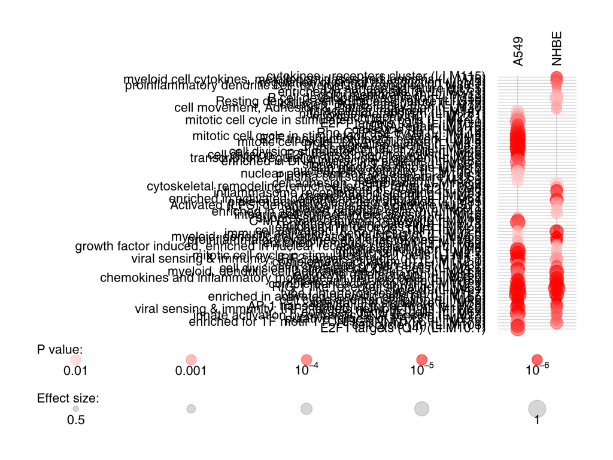

Ops, that did not go well…

## tmodPanelPlot

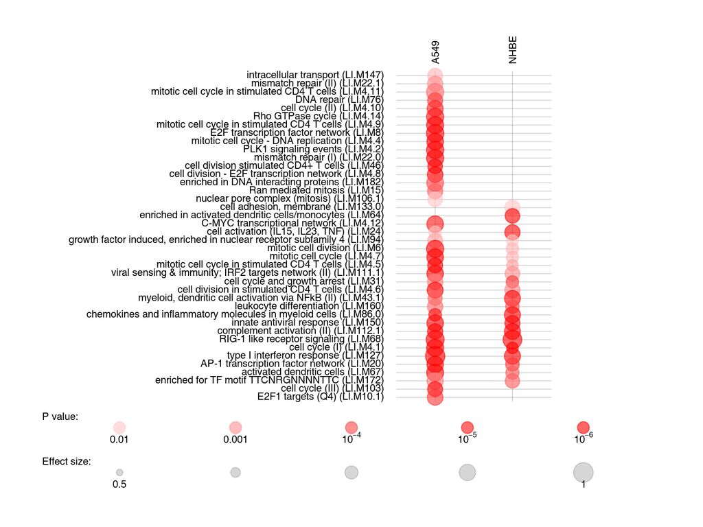

## tmodPanelPlot

But which genes go up, and which go down? We can add information about the significantly up- and down- regulated genes to the plot.

```r
tmp <- merge(res, res.nhbe, by="PrimaryID")
tmp <- na.omit(tmp)
## select log2 fold change columns
lfcs <- tmp[ , grep("log2FoldChange", colnames(tmp)) ]
colnames(lfcs) <- c("A549", "NHBE")

## select padj columns
qvals <- tmp[ , grep("padj", colnames(tmp)) ]
colnames(qvals) <- c("A549", "NHBE")

pie <- tmodDecideTests(tmp$SYMBOL.x, lfcs, qvals, lfc.thr=1, pval.thr=0.01)
```

## tmodPanelPlot

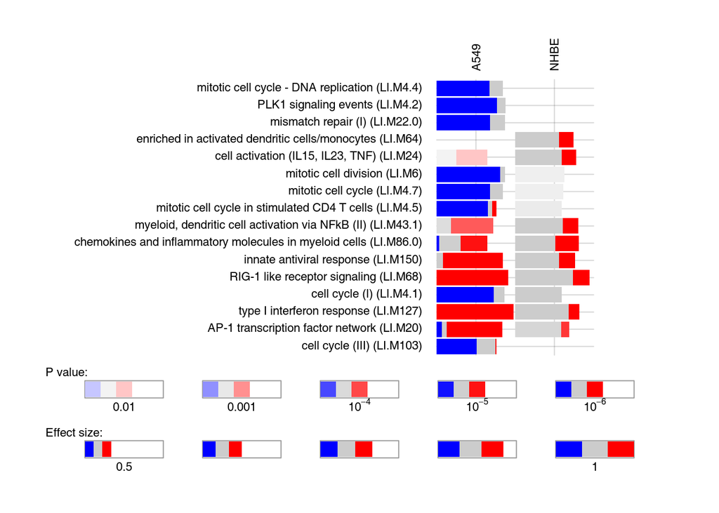

```r
tmodPanelPlot(x, filter.rows.auc=.8, filter.rows.pval=1e-7, text.cex=.7, pie=pie)
```

## clusterProfiler

Mostly uses the `DOSE` package for running the actual calcualtions.

- GSEA – general function
- gseGO – Gene ontologies
- gseKEGG - KEGG modules
- gseNCG – network of cancer genes